# Quantitative analysis of chlorophyll spectroscopic data: Differentiating Chl a and Chl f

Author: Hao-Li Huang  
Date modified: Feb 13, 2021  
Data sets: 6kmx, cone 1 and cone 3, formyl params, sharpened ESP

```python
from IPython.display import Image
import os, glob
import pandas as pd
import numpy as np
import re
import matplotlib.pyplot as plt
import seaborn as sns
from scipy.stats import norm
from sklearn.linear_model import LinearRegression
from sklearn.mixture import GaussianMixture
```

# 1. Introduction

## 1.1 Chlorophyll, Cryo-EM, and PSI

Chlorophylls are the green molecules used by photosynthetic organisms to harvest solar energy. They are also responsible for the green color of many plants, algae, and cyanobacteria.  
The most common kind of chlorophyll is chlorophyll a. In this analysis, however, we are interested in another kind of chlorophyll, chlorophyll f, which is found in far-red light adapted cyanobacteria, because chlorophyll f can absorb redder wavelengths compared to chlorophyll a.  
The two kinds of chlorophylls are extremely similar. The only difference is a methyl group in chl a being substituted by a formyl group. In other words, a hydrogen is substituted by an oxygen.  
Figures in the introduction courtesy of Dr. Chris Gisriel, Dr. Jimin Wang, and David Flesher.

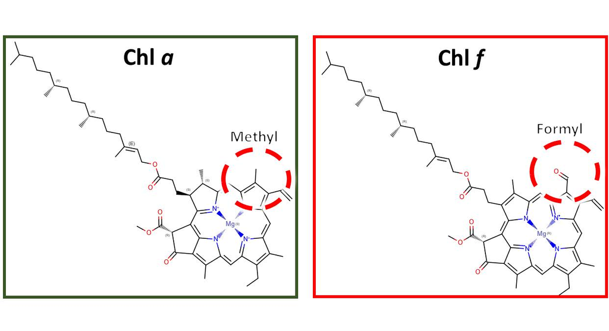

```python
Image('chl_comparison.jpg')
```

Cryogenic electron microscopy (cryo-EM) can determine high-resolution structures of biomolecules in solution. It reports the electrostatic potential in the space, which then can be used to model the structure.  
Below is a structure of photosystem I (PSI), which is a protein complex part of photosynthesis, in a far-red light (FRL) adapted cyanobacterium, with chlorophylls highlighted in green.

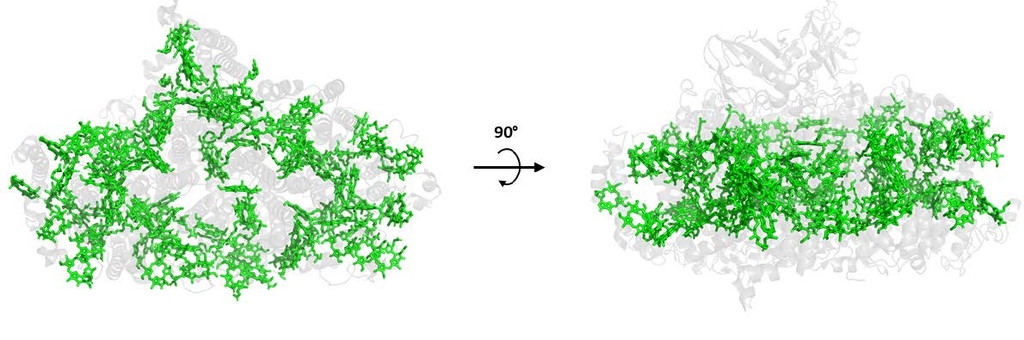

```python
Image('PSI.jpg')
```

Although the chls can be reliably identified in the Cryo-EM maps, the assignment of chl a and chl f is uncertain. In this analysis, we are interested in figuring out which of the chls above are chl f. This structural knowledge will help us understand the energetic landscape of the energy transfer in the protein complex.  
The method we use here is called 'cone scan', first described by my colleagues Chris Gisriel and Jimin Wang (published in Commucations Biology, https://doi.org/10.1038/s42003-020-01139-1). We look at the cone 1 and cone 3 positions of the chl, shown in the figure below. Cone 3 would be a methyl for both chl a and f, whereas cone 1 would be a methyl for chl a and formyl for chl f. Because oxygen of formyl groups is larger than hydrogen of methyl groups, the oxygen should have a larger electrostatic potential. We know the bond length of a C=O double bond and the C-C=O angle, so the possible location of the oxygen is the dashed circle in the figure. (i.e. The dihedral angle of the C-C=O and the porpherin can vary.) The scan around the C-C bond forms a cone shape, thus the name of 'cone scan'.

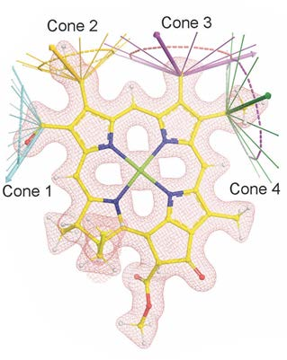

```python
Image('cone_scan.jpg')
```

Below is a figure of cone scan data of a chl f. The x-axis is the scan angle with respect to the porpherin (the big plane in the middle). Ideally, one should see a big peak at cone 1 and no signal at cone 3 for a chl f.

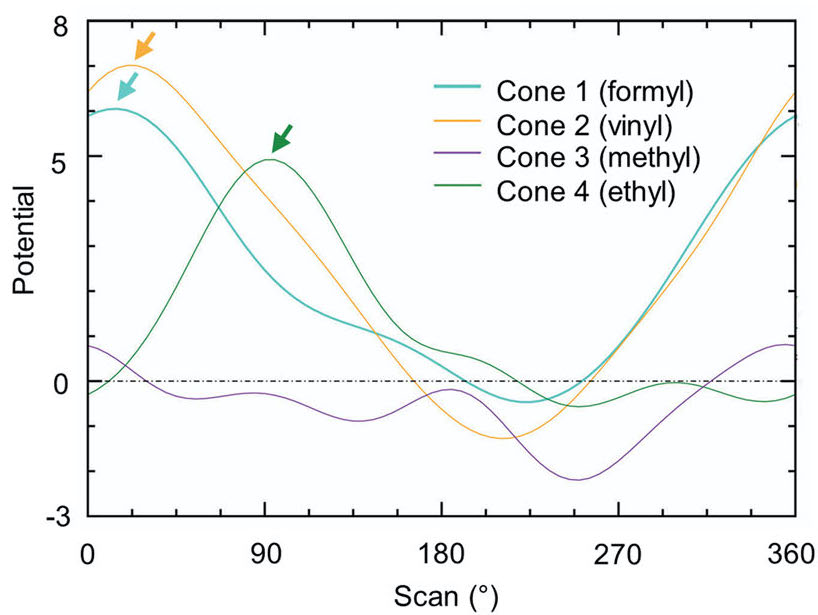

```python
Image('example_scan.jpg')
```

## 1.2 Objective

The goal of this analysis is to identify possible chlorophyll f using the Cryo-EM ESP map of the FRL-PSI structure (protein databank id: 6kmx).  
Becuase cone 3 is always methyl, we take it as the internal reference of the chlorophylls. The cone 3 scans gives us a baseline of how a methyl ESP looks like. Then, we take the cone 1 scan traces to see if they are similar to this baseline. If a trace is not similar to the baseline, it is likely that it is not a methyl, but a formyl substituent, thus a chl f.

# Functions

```python
def load_data(dirs):
    df = pd.DataFrame([])
    for i, d in enumerate(dirs):
        data = np.loadtxt(d, delimiter=' ')
        # Extract chl id from file names
        chl_id = re.findall('([A-Z]\d{3})_', d)[0].lower()
        # Column name: chl id; column values: electrostatic potentials
        df[chl_id] = data[:,1]
    # Index: scan angles
    angle = data[:,0].astype(int)
    df = df.set_index(angle)

    return df
```

```python
def plot_hist_norm(ax, df, row, xlim, label = None,
                   bar_color = 'tab:blue', curve_color = 'blue'):

    x = np.linspace(xlim[0], xlim[1], 100)   # x range for normal fitting
    bins = np.linspace(xlim[0], xlim[1], 15) # bin positions for histogram
    degrees = df.index                       # degrees for subplot title

    # Plot histogram
    ax.hist(df.iloc[row], bins=bins, density=True, alpha=0.7, color=bar_color, label=label)
    ax.axvline(0, c='black', linestyle='--', alpha=0.7)

    ### Normal fitting
    parameters = norm.fit(df.iloc[row])
    # now, parameters[0] and parameters[1] are the mean and
    # the standard deviation of the fitted distribution
    # Generate the pdf (fitted distribution)
    fitted_pdf = norm.pdf(x,loc = parameters[0],scale = parameters[1])

    # Plot Gaussian fit
    ax.plot(x,fitted_pdf,curve_color,linestyle="dashed", linewidth=2)
    ax.set_xlabel('Electrostatic Potential')
    ax.set_ylabel('Probability Density')
    ax.set_title(str(degrees[row].astype(int)) + ' degrees')
    if label:
        ax.legend(loc=1)
```

```python
def plot_cones(ax, Y_cone1, Y_cone3):
    ### Plot traces, one chl at a time
    X = Y_cone1.index
    ax.plot(X, Y_cone1, c='navy')
    ax.plot(X, Y_cone3, c='darkgreen')

    # Plot the mean values of the traces as horizontal lines
    ax.axhline(np.mean(Y_cone1), c='navy', linestyle='dotted', alpha=0.7)
    ax.axhline(np.mean(Y_cone3), c='darkgreen', linestyle='dotted', alpha=0.7)

    # Plot y=0
    ax.axhline(0, c='black', linestyle='--', alpha=0.7)
    ax.set_xlim([0, 355])
    ax.set_xlabel('Dihedral Angle (deg)')
    ax.set_ylabel('Electrostatic Potential')
```

```python
def plot_meanstd(ax, mean, std, n, c_mean='tab:orange', c_fill='tab:orange'):
    # mean is a df with scan angles as index and mean of each angle as value
    X = mean.index
    ax.plot(X, mean, c=c_mean, label='Cone 3 mean')
    ax.fill_between(X, mean+std*n, mean-std*n, alpha=0.3,
                    color=c_fill, label=str(n) + ' standard deviations')
```

```python
def plot_data(ax, X, Y, fs, color='tab:blue'):
    # X = X.append(pd.Index([360]))
    # Y = pd.concat([Y, Y.iloc[[0]]])
    X = Y.index
    ax.plot(X, Y, c=color)
    ax.axhline(0, c='black', linestyle='--', alpha=0.7)
    ax.set_xlim([0, 355])
    ax.set_xlabel('Dihedral Angle (deg)', fontsize=fs)
    ax.set_ylabel('Electrostatic Potential', fontsize=fs)
```

```python
def plot_traces_bin(Y1, Y3, title, n_std):
    ### Plot baseline (cone 3) of each bin
    l = len(unique_bin) # number of bins
    fig, axs = plt.subplots(3,l,figsize=(l*3, 10), sharex=True, sharey=True)
    fig.suptitle(title, fontsize=16)
    axs = axs.ravel()

    ## Plot each bin
    X = Y1.index
    for j in range(l):
        # chl id in this bin
        chl_id = res[res['bin']==unique_bin[j]].index
        # Cone 1 & 3 traces in this bin
        y1 = c1[chl_id]
        y3 = c3[chl_id]

        # First row: Cone 3 with mean and n_std standard deviations
        plot_data(axs[j], X, y3, 12)
        plot_meanstd(axs[j], y3.mean(1), y3.std(1), n_std) # Mask
        axs[j].set_title(str(unique_bin[j]) + ', cone 3')

        # Second row: Cone 1 with mean
        plot_data(axs[j+l], X, y1, 12)
        axs[j+l].plot(X, y1.mean(1), c='tab:red')
        axs[j+l].set_title(str(unique_bin[j]) + ', cone 1')

        # Third row: Cone 1 masked
        plot_data(axs[j+l*2], X, y1, 12)
        plot_meanstd(axs[j+l*2], y3.mean(1), y3.std(1), n_std) # Mask
        axs[j+l*2].set_title(str(unique_bin[j]) + ', cone 1, masked')

    for ax in axs.flat:
        ax.label_outer()
    fig.subplots_adjust(top=0.91) # Adjust space between title and figure
```

```python
def standardized_signal(c1, c3):
    stdrdz_sig = pd.DataFrame([])
    ### Get mean and std in each resolution bin
    for b in (unique_bin):
        chl_id = res[res['bin'] == b].index
        mean = c3[chl_id].mean(1)
        std = c3[chl_id].std(1)
        # Calculate standardized signals and put them in stdrdz_sig
        stdrdz_sig[chl_id] = c1[chl_id].apply(lambda col: (col-mean)/std)

    # Replace negative values to np.nan for easier presentation
    stdrdz_sig = stdrdz_sig.applymap(lambda x: x if x > 0 else np.NaN)

    # Temporarily append a row containing the max of each column for sorting purpose
    stdrdz_sig = stdrdz_sig.append(pd.Series(stdrdz_sig.max(), name = 'max'))
    stdrdz_sig = stdrdz_sig.sort_values(by='max', ascending=False, axis=1)

    # Drop the 'max' row and transpose for visualization
    stdrdz_sig = stdrdz_sig.drop('max').T

    return stdrdz_sig
```

```python
def chl_heatmap(chl_sig, title, cbar_size=1):
    plt.subplots(figsize=(6,chl_sig.shape[0]*0.4))
    ### Plot heatmap
    g = sns.heatmap(chl_sig, cmap='Greens', cbar_kws={"shrink": cbar_size})

    ### Format tick lables
    plt.setp(g.get_yticklabels(), rotation=0)
    # Color ytick labels according to resolution bin
    for i, tick_label in enumerate(g.axes.get_yticklabels()):
        if res.loc[chl_sig.index[i],'res'] <= 2.4:
            tick_label.set_color('g')
        elif res.loc[chl_sig.index[i],'res'] <= 2.6:
            tick_label.set_color('y')
        else:
            tick_label.set_color('r')
    g.set(xticks=np.arange(0, 72, 12))
    g.set(xticklabels=np.arange(0, 360, 60))
    plt.setp(g.get_xticklabels(), rotation=45)

    g.set_ylabel('Chlorophyll ID')
    g.set_xlabel('Dihedral Angle (deg)')
    g = plt.title(title)
```

```python
def highlight_traces_bin(Y1, Y3, title, n_std):
    ### Plot baseline (cone 3) of each bin
    l = len(unique_bin) # number of bins
    fig, axs = plt.subplots(3,l,figsize=(l*3, 10), sharex=True, sharey=True)
    fig.suptitle(title, fontsize=16)
    axs = axs.ravel()

    ### Get the chl ids to highlight
    stdrdz_sig = standardized_signal(c1, c3)
    highlight = (stdrdz_sig - n_std).applymap(lambda c:
                                    c if c > 0 else np.nan).dropna(how='all').index

    ## Plot each bin
    X = Y1.index
    for j in range(l):
        # chl id in this bin
        chl_id = res[res['bin']==unique_bin[j]].index

        chl_hl = chl_id.intersection(highlight)  # chl ids to highlight in this bin
        chl_nonhl = chl_id.difference(highlight) # chl ids to not highlight

        y1h = c1[chl_hl]    # Cone 1 traces to highlight in this bin
        y1n = c1[chl_nonhl] # Cone 1 traces to not highlight
        y1 = c1[chl_id]     # All cone 1 traces
        y3 = c3[chl_id]     # All cone 3 traces

        # First row: Cone 3 with mean and n_std standard deviations
        plot_data(axs[j], X, y3, 12)
        plot_meanstd(axs[j], y3.mean(1), y3.std(1), n_std)
        axs[j].set_title(str(unique_bin[j]) + ', cone 3')

        # Second row: Cone 1 with mean
        plot_data(axs[j+l], X, y1n, 12, 'tab:gray')    # Not highlight
        axs[j+l].plot(X, y1.mean(1), c='tab:green')
        plot_data(axs[j+l], X, y1h, 12, 'tab:red')     # Highlight
        axs[j+l].set_title(str(unique_bin[j]) + ', cone 1')

        # Third row: Cone 1 masked
        plot_data(axs[j+l*2], X, y1n, 12, 'tab:gray')  # Not highlight
        plot_meanstd(axs[j+l*2], y3.mean(1), y3.std(1), n_std, 'tab:blue', 'tab:blue')
        plot_data(axs[j+l*2], X, y1h, 12, 'tab:red')   # Highlight
        axs[j+l*2].set_title(str(unique_bin[j]) + ', cone 1, masked')

    for ax in axs.flat:
        ax.label_outer()
    fig.subplots_adjust(top=0.91)
```

```python
def highlight_traces_bin_ver2(Y1, Y3, title, n_std):
    ### Plot baseline (cone 3) of each bin
    l = len(unique_bin) # number of bins
    fig, axs = plt.subplots(3,l,figsize=(l*3, 10), sharex=True, sharey=True)
    fig.suptitle(title, fontsize=16)
    axs = axs.ravel()

    ### Get the chl ids to highlight
    stdrdz_sig = standardized_signal(c1, c3)
    highlight = (stdrdz_sig - n_std).applymap(lambda c:
                                    c if c > 0 else np.nan).apply(lambda col:
                                    np.nan if ((col.name >= 45) & (col.name <= 160)) |
                 ((col.name >= 205) & (col.name <= 330)) else col).dropna(how='all').index


    ## Plot each bin
    X = Y1.index
    for j in range(l):
        # chl id in this bin
        chl_id = res[res['bin']==unique_bin[j]].index

        # To highlight
        chl_hl = chl_id.intersection(highlight)
        chl_nonhl = chl_id.difference(highlight)

        y1h = c1[chl_hl]
        y1n = c1[chl_nonhl]
        y1 = c1[chl_id]
        y3 = c3[chl_id]

        # First row: Cone 3 with mean and n_std standard deviations
        plot_data(axs[j], X, y3, 12)
        plot_meanstd(axs[j], y3.mean(1), y3.std(1), n_std)
        axs[j].set_title(str(unique_bin[j]) + ', cone 3')

        # Second row: Cone 1 with mean
        plot_data(axs[j+l], X, y1n, 12, 'tab:gray')
        axs[j+l].plot(X, y1.mean(1), c='tab:green')
        if not chl_hl.empty:
            plot_data(axs[j+l], X, y1h, 12, 'tab:red')
        ylim = axs[j+1].get_ylim()
        axs[j+l*1].fill_between([45,160], ylim[1], ylim[0], alpha=0.2, color='grey')
        axs[j+l*1].fill_between([205,330], ylim[1], ylim[0], alpha=0.2, color='grey')
        axs[j+l].set_title(str(unique_bin[j]) + ', cone 1')

        # Third row: Cone 1 masked
        plot_data(axs[j+l*2], X, y1n, 12, 'tab:gray')
        plot_meanstd(axs[j+l*2], y3.mean(1), y3.std(1), n_std, 'tab:blue', 'tab:blue')
        axs[j+l*2].fill_between([45,160], ylim[1], ylim[0], alpha=0.2, color='grey')
        axs[j+l*2].fill_between([205,330], ylim[1], ylim[0], alpha=0.2, color='grey')
        if not chl_hl.empty:
            plot_data(axs[j+l*2], X, y1h, 12, 'tab:red')
        axs[j+l*2].set_title(str(unique_bin[j]) + ', cone 1, masked')
        axs[j+1*2].set_ylim(ylim)

    for ax in axs.flat:
        ax.label_outer()
    fig.subplots_adjust(top=0.91)
```

# 2. Load Data

```python
### Generate directories of ESP files
c1_dir = sorted(glob.glob(os.path.join('cone1', '*')))
c3_dir = sorted(glob.glob(os.path.join('cone3z', '*')))
```

```python
### Load resolutions as pandas dataframe
res = pd.read_csv('6kmx_resolutions.csv')
# Combine chain and resi to the same column
res['chl'] = res['chain'] + res['resi'].astype(str)
res.drop(['chain', 'resi'], axis=1, inplace=True)

res.sort_values('chl', inplace=True)
res.columns = (['res', 'chl'])
res = res.set_index('chl')
```

```python
### Load data: formyl parameters, cone 1 and 3
# Index: scan angle; column: chlorophyll id; value: electrostatic potential
c1 = load_data(c1_dir)
c3 = load_data(c3_dir)
```

# 3. Preliminary Exploration

## 3.1 Individual traces sorted by resolution

First, I plot each trace, cone 1 and cone 3 from 90 chlorophylls to get a general feeling of what data we are dealing with. The chls are sorted with decreasing resolution (increasing value), so it is easier to see a decrease of fluctuation.

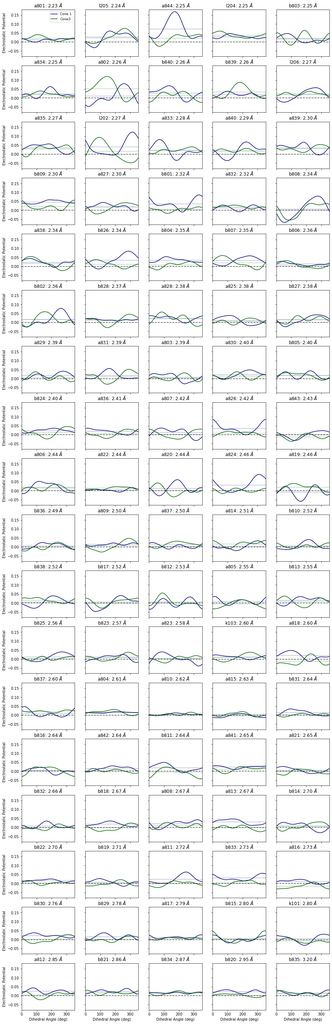

```python
n_chl = c1.shape[1]           # Number of chlorophylls in this analysis
n_row = int(np.ceil(n_chl/5)) # Calculate number of rows for 5 columns
res = res.sort_values('res')  # Sort by resolution
fig, axs = plt.subplots(n_row,5, figsize=(15, 50), sharex=True, sharey=True)
axs = axs.ravel()

for i in range(n_chl):
    chl_id = res.index[i]
    plot_cones(axs[i], c1[chl_id], c3[chl_id])
    axs[i].set_title(chl_id + ': ' + str("%.2f " %res.loc[chl_id, 'res']) + r'$\AA$')

for i in range(n_chl, n_row*5):
    axs[i].set_xlabel('Dihedral Angle (deg)')

fig = axs[0].legend(['Cone 1', 'Cone3'], fontsize=9)
for ax in axs.flat:
    ax.label_outer()
```

## 3.2 Baseline distribution

Check the distribution of the baseline (cone 3) signal at different scan angles. There are 90 chls in this dataset, so at each scan angle, there are 90 values corresponding to each chl.  
Below, we look at the distributions at every 30 degrees. As expected, the distributions are normal, allowing us to quite easily compare this with the cone 1 signals, which may be methyl or formyl.

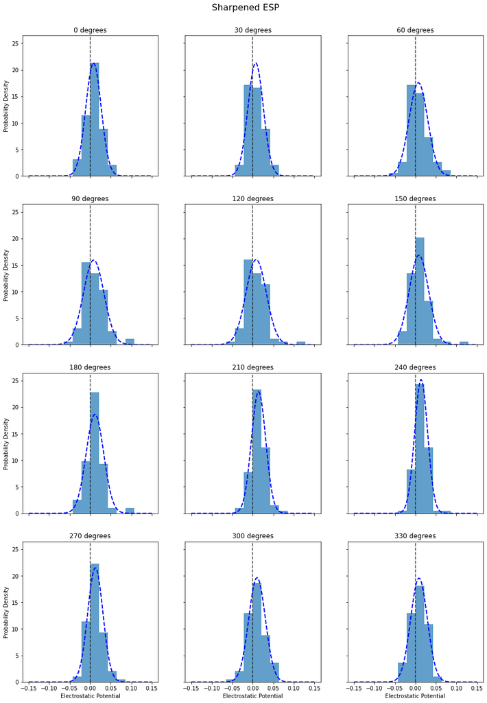

```python
fig, axs = plt.subplots(4,3,figsize=(15, 20), sharex=True, sharey=True)
fig.suptitle('Sharpened ESP', fontsize = 16)

axs = axs.ravel()
for i in range(12):
    plot_hist_norm(axs[i], c3, i*6, [-0.15, 0.15])
for ax in axs.flat:
    ax.label_outer()

fig.subplots_adjust(top=0.94)
```

## 3.3 Resolution and fluctuation

From **3.1**, we see roughly the higher the resolution (lower the value), the larger fluctation of the traces. Here, we quantify the fluctuation by calculating the standard deviation of the traces.

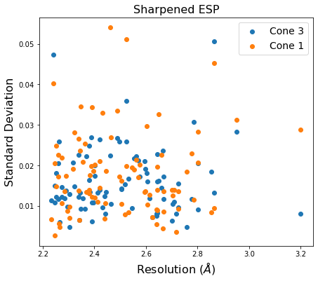

```python
fig, ax = plt.subplots(figsize=(7, 6))

ax.scatter(res, c3.std(), label='Cone 3')
ax.scatter(res, c1.std(), label='Cone 1')
ax.set_xlabel('Resolution ' + r'$(\AA)$', fontsize=16)
ax.set_ylabel('Standard Deviation', fontsize=16)
ax.set_title('Sharpened ESP',fontsize=16)
fig = ax.legend(fontsize=14)
```

Looking only at the baseline (cone 3), there is a very weak correlation between resolution and fluctuation.

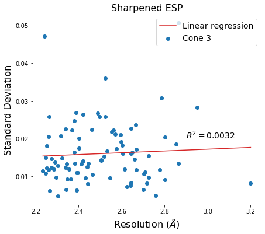

```python
### Linear regression using sklearn
X = np.array(res['res']).reshape(-1,1)
y = c3.std()
model = LinearRegression()
model.fit(X, y)
r_sq = model.score(X, y)
y_pred = model.predict(X)

# Plot
fig, ax = plt.subplots(figsize=(7, 6))
ax.scatter(X, y, label='Cone 3')
ax.plot(X, y_pred, c='tab:red', label='Linear regression')
ax.set_xlabel('Resolution ' + r'$(\AA)$', fontsize=16)
ax.set_ylabel('Standard Deviation', fontsize=16)
ax.text(2.9, 0.02, r'$R^2 = $' + str("%.4f " %r_sq), fontsize=14)
ax.set_title('Sharpened ESP', fontsize=16)
fig = ax.legend(fontsize=14)
```

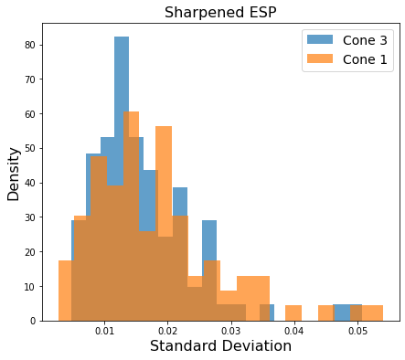

```python
fig, ax = plt.subplots(figsize=(7, 6))

ax.hist(c3.std(), bins=20, density=True, label='Cone 3', alpha=.7)
ax.hist(c1.std(), bins=20, density=True, label='Cone 1', alpha=.7)
ax.set_xlabel('Standard Deviation', fontsize=16)
ax.set_ylabel('Density', fontsize=16)
ax.set_title('Sharpened ESP', fontsize=16)
fig = ax.legend(fontsize=14)
```

Although the correlation between resolution and fluctuation is weak, we think it still makes sense to split the data into resolution bins, demonstrated below.

# 4. Possible Chlorophyll *f*'s

I tried to identify a small group of traces that are disimilar to the rest using two methods. First, I used the Gaussian Mixture Model to cluster the traces into three groups, one big group corresponding to Chl a, and two small groups to Chl f. Second, I identified the traces with large peak values by comparing them with the baseline level derived using cone 3.

## 4.1 Gaussian Mixture Model

Clustering using Gaussian Mixture Model. The underlying assumption here is that the shape of the cone 1 trace of a methyl substituent would look different from that of a formyl substitutent. In addition, there should be two groups of formyl traces, with the oxygen pointing towards 0 and 180 degrees. Thus, the number of components in the Gaussian Mixture Model is set to be 3. The outcome may be different depending on the random initialization.

```python
def plot_gaussian_mixture(X, random_state=None):
    X = X.T
    ### Gaussian mixture model. Because the 'full' covariance type leads
    ### to overfitting, here we choose to use 'tied'.
    gmm = GaussianMixture(n_components=3, random_state=random_state,
                          n_init=50, covariance_type='tied').fit(X)
    pred = gmm.predict(X)

    ### Sort clusters. Second largest cluster called group 1, and
    ### smallest cluster called group 2. These two groups likely
    ### correspond to formyl substituents
    count = (np.count_nonzero(pred==0), np.count_nonzero(pred==1),
             np.count_nonzero(pred==2))
    cat = sorted(range(len(count)), key=count.__getitem__, reverse=True)

    rest = X[pred==cat[0]]
    group1 = X[pred==cat[1]]
    group2 = X[pred==cat[2]]

    ### Plot clusters
    fig, ax = plt.subplots(figsize=(6, 6))
    ax.plot(rest.T.index, rest.T, color='grey')
    ax.plot(group1.T.index, group1.T, color='red')
    ax.plot(group2.T.index, group2.T, color='blue')
    ax.axhline(0, c='black', linestyle='--', alpha=0.7)
    ax.set_xlim([0, 355])
    ax.set_xlabel('Dihedral Angle (deg)')
    ax.set_ylabel('Electrostatic Potential');

    print('group 1 (red): {}'.format(list(X[pred==cat[1]].index)))
    print('group 2 (blue): {}'.format(list(X[pred==cat[2]].index)))
```

### Outcome 1

```
group 1 (red): ['a824', 'a826', 'b801', 'b826', 'l202']
group 2 (blue): ['a844']
```

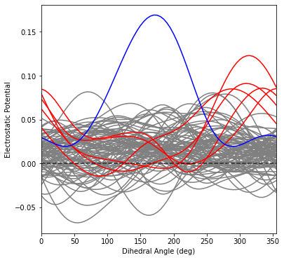

```python
plot_gaussian_mixture(X=c1, random_state=4)
```

### Outcome 2

```
group 1 (red): ['a824', 'a826', 'b801', 'b826', 'l202']
group 2 (blue): ['a834', 'a835', 'a839', 'a844']
```

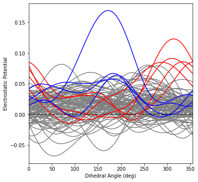

```python
plot_gaussian_mixture(X=c1, random_state=0)
```

### Outcome 3

There are too many Chls in group 1, making this outcome unlikely to be true.

```
group 1 (red): ['a802', 'a811', 'a824', 'a830', 'a834', 'a840', 'b802', 'b807', 'b808', 'b809', 'b826', 'l202', 'l205', 'l206']
group 2 (blue): ['a844']
```

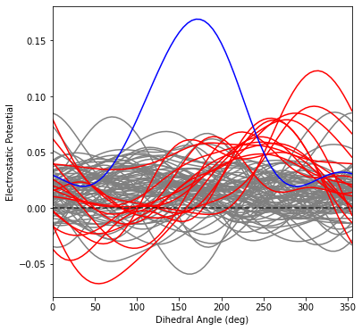

```python
plot_gaussian_mixture(X=c1, random_state=1)
```

## 4.2 Identifying Traces with Large Peak Values

### Three resolution bins, cut off at 2.4 and 2.6 angstroms

The chlorophylls are first split into resolution bins, and then passed into the function `standardized_signal`. The output corresponds to how many standard deviations the cone 1 signal is above the mean of the cone 3 signal.
$$ \mathrm{\frac{Signal(cone\ 1)-Mean(cone\ 3)}{SD(cone\ 3)}} $$
The mean and standard deviation are only taken from the cone 3 signals in the corresponding resolution bin.
Here I only keep the positive values and replace the negative ones with NaN (not a number).

```python
# Cut-offs
cutoff = [0, 2.4, 2.6, 5.0]

# Get the res bins using the pd.cut function
res['bin'] = pd.cut(res['res'], cutoff)
unique_bin = sorted(res['bin'].unique())
```

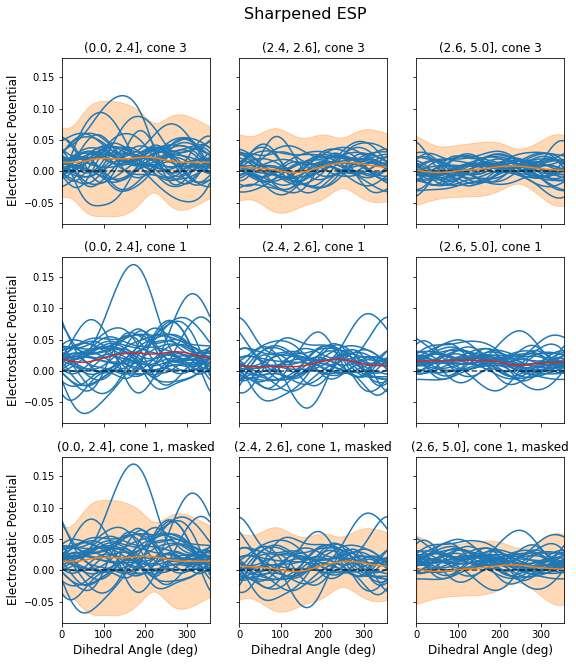

```python
plot_traces_bin(c1, c3, 'Sharpened ESP', 3)
```

In the last row, we compare the cone 1 traces with the mean of cone 3 (orange line) and 3 standard deviations of cone 3 (orange shade), which defines the baseline level in this analysis. The cone 1 traces that sticks out of the orange shade is considered dissimilar to methyl data. These chls are listed in the heatmap below. The label color corresponds to the resolution bin. Green is the highest resolution, yellow middle, and red lowest. The heatmap shows how many standard deviations this cone 1 signal sticks out of the baseline.

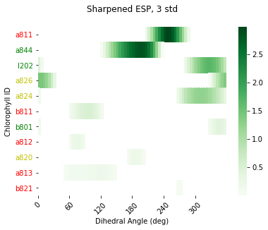

```python
### Get standardized signal
stdrdz_sig = standardized_signal(c1, c3)
# Only look at the signals that are larger than 3 stadandard deviations
std3 = (stdrdz_sig - 3).applymap(lambda c: c if c > 0 else np.nan).dropna(how='all')
# Make heat plot
title = 'Sharpened ESP, 3 std\n'
chl_heatmap(std3, title, cbar_size=1)
```

A variation of the figure above, with the dissimilar traces highlighted.

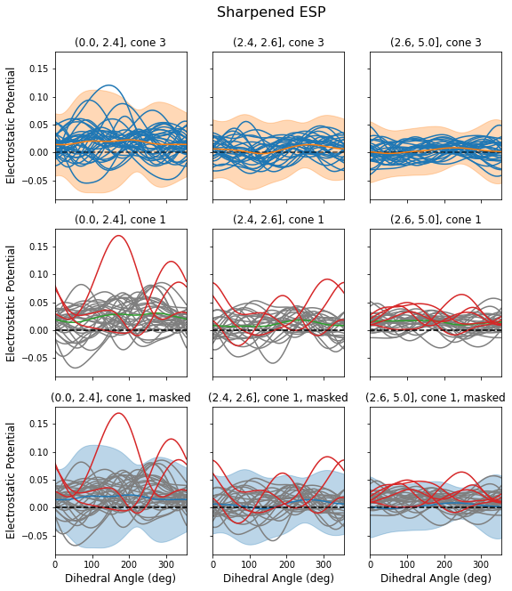

```python
highlight_traces_bin(c1, c3, 'Sharpened ESP', 3)
```

I further filtered out the traces with peaks at improbable angles, and only highlight the probable traces.

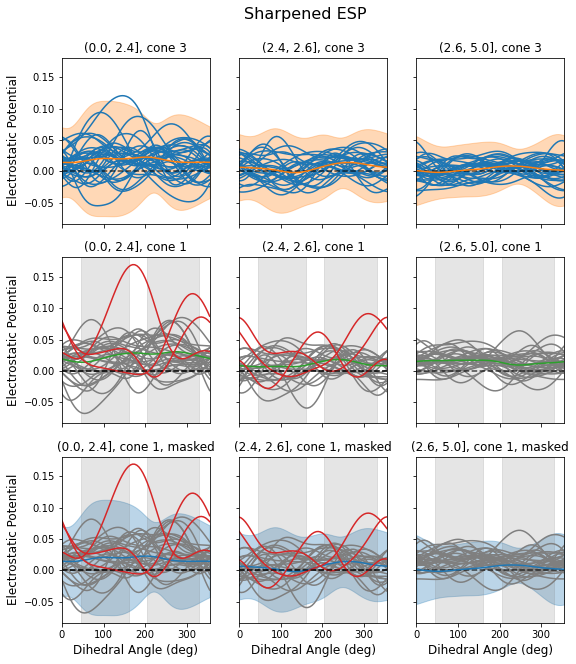

```python
highlight_traces_bin_ver2(c1, c3, 'Sharpened ESP', 3)
```

```python
### Get standardized signal
c1_truncated = c1.apply(lambda row:
                 np.nan if ((row.name >= 45) & (row.name <= 160)) |
                 ((row.name >= 205) & (row.name <= 330)) else row, axis=1)
c3_truncated = c3.apply(lambda row:
                 np.nan if ((row.name >= 45) & (row.name <= 160)) |
                 ((row.name >= 205) & (row.name <= 330)) else row, axis=1)
stdrdz_sig = standardized_signal(c1_truncated, c3_truncated)
```

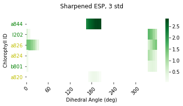

```python
std3 = (stdrdz_sig - 3).applymap(lambda c: c if c > 0 else np.nan).dropna(how='all')
# Make heat plot, filtering out improbable angles
title = 'Sharpened ESP, 3 std\n'
chl_heatmap(std3, title, cbar_size=1)
```

However, due to the inherent difficulties of identifying single atoms using Cryo-EM, definitive assignments can't be made using these analysis alone. Other indirect evidence are needed to help identify Chl f. However, this method provides a quantitative way to pick out possible candidtates for Chl f.  
It is worth mentioning that 66% of the possible Chl f's identified by these methods are consistent with those that are already suggested by other evidence to be Chl f's (more details in the manuscript, to be updated upon publication). This demonstrates that the quantitative analyses do produce consistent and sensible results, albeit the mediocre data quality (resulted from the structural resolution).